# Module 1

# Module 3

## Scrapping details of all playlist along with url

1. This module collects information about the playlists.
2. Here, data from 'WION' news channel is collected.
3. The data consists of recent playlist.
4. The data frommultiple playlists gives overall news topics around the world.
5. From this data, information is collected and sentiment analysis is done.
6. This sentiment tells us about public mindset about recent events happening around the world.

```python
# Function to extract most popular news topics from playlists

# Initializing driver

print('Initializing driver....')
driver = start_chrome(maximize=True) # Maximize window

# Channel name and youtube url

channel_name='wion'
url='https://www.youtube.com/c/'+channel_name+'/playlists'
print(url)
print('Fetching URL...')

# Loading URL

go_to(url)
time.sleep(2)
print('URL fetched....')

# Setting page height

h=300
print('Scraping phase-1 started...')

# Creating empty list to store data

output_text=[]

# Scrolling upto specified height

for i in tqdm(range(40)):
    scroll_down(h)
    time.sleep(0.2)
    h+=300

# Phase-1
# Extracting the playlist title, video_link and palylist_link

title=[i.text for i in driver.find_elements_by_id('video-title')]
vdo_link=[i.get_attribute('href') for i in driver.find_elements_by_id('video-title')]
playlist_links=[i.get_attribute('href') for i in driver.find_elements_by_xpath("""//*[@id="view-more"]/a""")]
print('Scraping phase 1 successfully completed...')

# Phase-2

print('Scaping phase-2 started....')

# Using loop to get top news title in each playlist
print(f"total {len(playlist_links)} playlists found")
for i in tqdm(playlist_links):
    go_to(i)
    time.sleep(1.5)
    for j in range(10):
        scroll_down(h)
        time.sleep(0.3)
        h+=300
    time.sleep(2)
    vdo_ttl=[t.text for t in driver.find_elements_by_id('video-title')]
    output_text.append(vdo_ttl)
raw_text=[]
for i in output_text:
    for j in i:
        raw_text.append(j)
print('Scraping phase 2 successfully completed....')
print('Scraping done successfully without any error!')
```

```
Initializing driver....
https://www.youtube.com/c/wion/playlists
Fetching URL...
```

```
URL fetched....
Scraping phase-1 started...
```

```
Scraping phase 1 successfully completed...
Scaping phase-2 started....
total 292 playlists found
```

```
Scraping phase 2 successfully completed....
Scraping done successfully without any error!
```

```python
len(raw_text)
```

```
11936
```

```python
raw_text[0]
```

```
'The Good Life | Internal Shower: The latest life hack | Top English News | WION'
```

```python
TextBlob(raw_text[0]).correct()
```

```
TextBlob("The Good Life | Internal Shower: The latest life hack | Top English News | WION")
```

```python
TextBlob('liken').correct()
```

```
TextBlob("like")
```

```python
df=pd.DataFrame({'Title': raw_text})
df.head()
```

|  | Title |
| --- | --- |
| 0 | The Good Life \| Internal Shower: The latest li... |
| 1 | The Good Life: Social media is not your dermat... |
| 2 | The Good Life: Yoga is not a trend but a lifes... |
| 3 | The Good Life: Decoding the 80/20 rule for the... |
| 4 | The Good Life: Forget about avocado and quinoa... |

```python
len(df)
```

```
11936
```

```python
df['Polarity']=[TextBlob(i).sentiment.polarity for i in df['Title']]
```

```python
def senti(x):
    if x<0:
        return "Negative"
    elif  x ==0:
        return "Neutral"
    else:
        return "positive"

df['Sentiment'] = df['Polarity'].apply(senti)
```

```python
df.head()
```

|  | Title | Polarity | Sentiment |
| --- | --- | --- | --- |
| 0 | The Good Life \| Internal Shower: The latest li... | 0.340000 | positive |
| 1 | The Good Life: Social media is not your dermat... | 0.366667 | positive |
| 2 | The Good Life: Yoga is not a trend but a lifes... | 0.350000 | positive |
| 3 | The Good Life: Decoding the 80/20 rule for the... | 0.622222 | positive |
| 4 | The Good Life: Forget about avocado and quinoa... | 0.875000 | positive |

```python
df.tail()
```

|  | Title | Polarity | Sentiment |
| --- | --- | --- | --- |
| 11931 | Yellow vest protests erupt again in Paris, as ... | 0.000000 | Neutral |
| 11932 | China in 'strong protest' to US over Meng Wanz... | 0.191667 | positive |
| 11933 | France protests: Government fears 'major viole... | 0.062500 | positive |
| 11934 | Your Story : Cambridge Analytica used fashion ... | 0.000000 | Neutral |
| 11935 | UK suspends ‘golden visas’ in money laundering... | 0.300000 | positive |

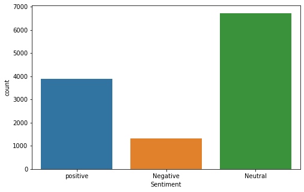

```python
plt.figure(figsize=(8,5))
sns.countplot(x='Sentiment',data=df)
```

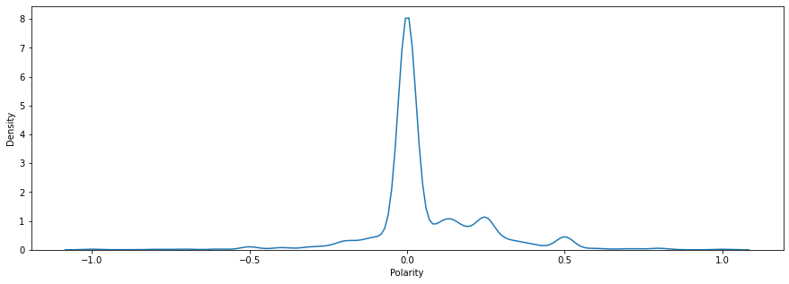

```python
plt.figure(figsize=(15,5))
sns.kdeplot(x='Polarity',data=df)
```

# Module 4

1. Using this data, future views per day is predicted using ML model.
2. If any new video is uploaded then the future views on that video is predicted using algorithms.

```python
# Initializing driver
print('Initializing driver.....')
driver = start_chrome(maximize=True)
channel_name='wion'

# Navigate to url

print('Navigating to URL.....')
go_to(('https://www.youtube.com/c/'+channel_name+'/videos'))
time.sleep(2)
h=0
for i in tqdm(range(300)):
    scroll_down(h)
    time.sleep(1)
    h+=300
time.sleep(5)
info_box=[i.text for i in driver.find_elements_by_id('dismissible')]
print('Scraping done.....raw output file created.')
driver.quit()
```

```
Initializing driver.....
Navigating to URL.....
```

```
Scraping done.....raw output file created.
```

```python
len(info_box)
```

```
8549
```

```python
info_box[0]
```

```
'Gravitas with Palki Sharma: Are you suffering from long Covid? | Wuhan Virus | WION\n972 views\n27 minutes ago'
```

```python
duration=[]
news_heading=[]
views=[]
upload_time=[]
for i in info_box:
    dummy=i.split('\n')
    if len(dummy)<=3:
        news_heading.append(dummy[0])
        views.append(dummy[1].split()[0])
        upload_time.append(dummy[2])
    else:
        duration.append(dummy[0])
        news_heading.append(dummy[1])
        views.append(dummy[2].split()[0])
        upload_time.append(dummy[3])
```

```python
raw_data=pd.DataFrame({
    'News_Heading':news_heading,
    'Views':views,
    'Upload_Datetime':upload_time
})

raw_data.head()
```

|  | News_Heading | Views | Upload_Datetime |
| --- | --- | --- | --- |
| 0 | Gravitas with Palki Sharma: Are you suffering ... | 972 | 27 minutes ago |
| 1 | Holiday like Vladimir Putin? Head to Siberia \|... | 1.5K | 32 minutes ago |
| 2 | Report: Former South African President Jacob Z... | 1.3K | 39 minutes ago |
| 3 | Gravitas: Samsung fined $9 Million in Australi... | 3.3K | 44 minutes ago |
| 4 | Saudi-Israel normalisation on cards? \| Latest ... | 2.2K | 47 minutes ago |

```python
len(raw_data)
```

```
8549
```

```python
upt=[]
for i in raw_data['Upload_Datetime']:
    lst=i.split('Streamed',1)[-1].strip().split()
    if 'minutes' in lst:
        upt.append(1)
    elif 'minute' in lst:
        upt.append(1)
    elif 'day' in lst:
        upt.append(int(lst[0]))
    elif 'days' in lst:
        upt.append(int(lst[0]))
    elif 'week' in lst:
        upt.append(int(lst[0])*7)
    elif 'weeks' in lst:
        upt.append(int(lst[0])*7)
    elif 'month' in lst:
        upt.append(int(lst[0])*30)
    elif 'months' in lst:
        upt.append(int(lst[0])*30)
    elif 'year' in lst:
        upt.append(int(lst[0])*12*30)
    elif 'years' in lst:
        upt.append(int(lst[0])*12*30)
    else:
        upt.append(1)

raw_data['Days_from_upload']=upt
raw_data.head()
```

|  | News_Heading | Views | Upload_Datetime | Days_from_upload |
| --- | --- | --- | --- | --- |
| 0 | Gravitas with Palki Sharma: Are you suffering ... | 972 | 27 minutes ago | 1 |
| 1 | Holiday like Vladimir Putin? Head to Siberia \|... | 1.5K | 32 minutes ago | 1 |
| 2 | Report: Former South African President Jacob Z... | 1.3K | 39 minutes ago | 1 |
| 3 | Gravitas: Samsung fined $9 Million in Australi... | 3.3K | 44 minutes ago | 1 |
| 4 | Saudi-Israel normalisation on cards? \| Latest ... | 2.2K | 47 minutes ago | 1 |

```python
clean_views=[]
for i in raw_data.Views:
    dum=list(i)
    if 'K' in dum:
        clean_views.append(float(i.split('K')[0])*1000)
    elif 'L' in dum:
        clean_views.append(1000)
    elif 'M' in dum:
        clean_views.append(float(i.split('M')[0])*1000000)
    else:
        clean_views.append(float(i.split()[0]))

raw_data['Clean_views']=clean_views
raw_data.head()
```

|  | News_Heading | Views | Upload_Datetime | Days_from_upload | Clean_views |
| --- | --- | --- | --- | --- | --- |
| 0 | Gravitas with Palki Sharma: Are you suffering ... | 972 | 27 minutes ago | 1 | 972.0 |
| 1 | Holiday like Vladimir Putin? Head to Siberia \|... | 1.5K | 32 minutes ago | 1 | 1500.0 |
| 2 | Report: Former South African President Jacob Z... | 1.3K | 39 minutes ago | 1 | 1300.0 |
| 3 | Gravitas: Samsung fined $9 Million in Australi... | 3.3K | 44 minutes ago | 1 | 3300.0 |
| 4 | Saudi-Israel normalisation on cards? \| Latest ... | 2.2K | 47 minutes ago | 1 | 2200.0 |

```python
raw_data['Views_per_day']=round(raw_data['Clean_views']/raw_data['Days_from_upload'])
raw_data.head()
```

|  | News_Heading | Views | Upload_Datetime | Days_from_upload | Clean_views | Views_per_day |
| --- | --- | --- | --- | --- | --- | --- |
| 0 | Gravitas with Palki Sharma: Are you suffering ... | 972 | 27 minutes ago | 1 | 972.0 | 972.0 |
| 1 | Holiday like Vladimir Putin? Head to Siberia \|... | 1.5K | 32 minutes ago | 1 | 1500.0 | 1500.0 |
| 2 | Report: Former South African President Jacob Z... | 1.3K | 39 minutes ago | 1 | 1300.0 | 1300.0 |
| 3 | Gravitas: Samsung fined $9 Million in Australi... | 3.3K | 44 minutes ago | 1 | 3300.0 | 3300.0 |
| 4 | Saudi-Israel normalisation on cards? \| Latest ... | 2.2K | 47 minutes ago | 1 | 2200.0 | 2200.0 |

```python
raw_data.tail()
```

|  | News_Heading | Views | Upload_Datetime | Days_from_upload | Clean_views | Views_per_day |
| --- | --- | --- | --- | --- | --- | --- |
| 8544 | Straight Talk: Sri Lanka's Energy Minister Uda... | 4.3K | 4 months ago | 120 | 4300.0 | 36.0 |
| 8545 | Russia expands its sanctions list of EU offici... | 162K | 4 months ago | 120 | 162000.0 | 1350.0 |
| 8546 | Straight Talk: Sri Lanka's Energy Minister Uda... | 4K | Streamed 4 months ago | 120 | 4000.0 | 33.0 |
| 8547 | Zoo air becomes essential catalyst for DNA tes... | 3.7K | 4 months ago | 120 | 3700.0 | 31.0 |
| 8548 | France & its European partners are pushing to ... | 55K | 4 months ago | 120 | 55000.0 | 458.0 |

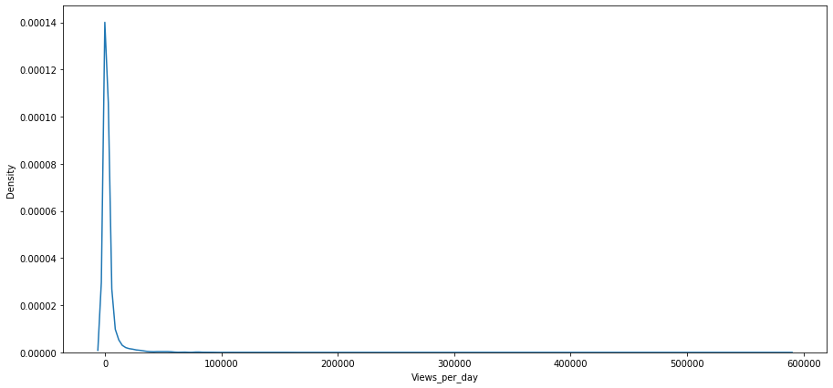

```python
plt.figure(figsize=(15,7))
sns.kdeplot(raw_data['Views_per_day']);
```

```python
raw_data.to_csv('120_day_news_data.csv')
```

```python
df=pd.read_csv('120_day_news_data.csv')
df.head()
```

|  | Unnamed: 0 | News_Heading | Views | Upload_Datetime | Days_from_upload | Clean_views | Views_per_day |
| --- | --- | --- | --- | --- | --- | --- | --- |
| 0 | 0 | Gravitas with Palki Sharma: Are you suffering ... | 972 | 27 minutes ago | 1 | 972.0 | 972.0 |
| 1 | 1 | Holiday like Vladimir Putin? Head to Siberia \|... | 1.5K | 32 minutes ago | 1 | 1500.0 | 1500.0 |
| 2 | 2 | Report: Former South African President Jacob Z... | 1.3K | 39 minutes ago | 1 | 1300.0 | 1300.0 |
| 3 | 3 | Gravitas: Samsung fined $9 Million in Australi... | 3.3K | 44 minutes ago | 1 | 3300.0 | 3300.0 |
| 4 | 4 | Saudi-Israel normalisation on cards? \| Latest ... | 2.2K | 47 minutes ago | 1 | 2200.0 | 2200.0 |

```python
# Top 10 news as per views per day

df.sort_values(by='Views_per_day',ascending=False)[:10]
```

|  | Unnamed: 0 | News_Heading | Views | Upload_Datetime | Days_from_upload | Clean_views | Views_per_day |
| --- | --- | --- | --- | --- | --- | --- | --- |
| 156 | 156 | Moscow fumes over Lithuanian ban: 'Your citize... | 584K | 1 day ago | 1 | 584000.0 | 584000.0 |
| 92 | 92 | Gravitas: Russian Rouble surges as Asian curre... | 341K | 1 day ago | 1 | 341000.0 | 341000.0 |
| 94 | 94 | Gravitas: Putin: Russia will use nukes to defe... | 322K | 1 day ago | 1 | 322000.0 | 322000.0 |
| 72 | 72 | BRICS summit 2022: Xi Jinping warns about 'exp... | 240K | 18 hours ago | 1 | 240000.0 | 240000.0 |
| 7377 | 7377 | Gravitas Plus \| Explained: The Russia-Ukraine ... | 26M | 4 months ago | 120 | 26000000.0 | 216667.0 |
| 351 | 351 | US President Joe Biden falls off bike during t... | 1M | 5 days ago | 5 | 1000000.0 | 200000.0 |
| 100 | 100 | Gravitas Live with Palki: Putin threatens to u... | 198K | Streamed 1 day ago | 1 | 198000.0 | 198000.0 |
| 2652 | 2652 | Gravitas Plus: Which countries could go the Sr... | 5.3M | 1 month ago | 30 | 5300000.0 | 176667.0 |
| 153 | 153 | Russia-Ukraine conflict: Fight for Severodonet... | 154K | 1 day ago | 1 | 154000.0 | 154000.0 |
| 251 | 251 | Gravitas: Is Israel preparing to attack Iran? | 451K | 3 days ago | 3 | 451000.0 | 150333.0 |

```python
stop=[i for i in stopwords.words('english') if i not in ['not','no','don','won','ain','nor','aren','very']]
unwanted_words=['gravitas','news','exclusive','english','wion','latest','live','reports','world','palki','sharma','streaming','plus','report']
wnl=WordNetLemmatizer()
```

```python
data=df[['News_Heading','Views_per_day']]
data.head()
```

|  | News_Heading | Views_per_day |
| --- | --- | --- |
| 0 | Gravitas with Palki Sharma: Are you suffering ... | 972.0 |
| 1 | Holiday like Vladimir Putin? Head to Siberia \|... | 1500.0 |
| 2 | Report: Former South African President Jacob Z... | 1300.0 |
| 3 | Gravitas: Samsung fined $9 Million in Australi... | 3300.0 |
| 4 | Saudi-Israel normalisation on cards? \| Latest ... | 2200.0 |

```python
## Cleaning the data

def Clean_text(text):
    text= text.lower()
    text= re.sub(r"cant", "can not", text)
    text= re.sub(r"won't", "will not", text)
    text= re.sub(r"cant", "can not", text)
    text= re.sub(r"wont", "will not", text)
    text= re.sub(r"dont", "do not", text)
    text= re.sub(r"n't", " not", text)
    text= re.sub(r"\'ll", " will", text)
    text= re.sub(r"arent", "are not", text)
    xv=[]
    for i in text.split():
        if i.isalpha()==True:
            xv.append(i)
        elif i.isdigit()==True:
            xc=' '.join(num2words(i).split('-'))
            xv.append(xc)
        else:
            hmm=[]
            for j in i:
                if j.isalpha()==True:
                    hmm.append(j)
                else:
                    hmm.append(' ')
            xv.append(''.join([k for k in hmm]))
    text=' '.join(xv)
    text = re.sub("[^a-zA-Z]", " ", text)
    text = re.sub("\s+", " ", text)
    text=' '.join([i for i in text.split() if i not in stop])
    text=' '.join([i for i in text.split() if i not in unwanted_words ])
    text=' '.join([wnl.lemmatize(i) for i in text.split()])

    return text
```

```python
data['review_text']=data['News_Heading'].apply(lambda x : Clean_text(x))
```

```python
data.head()
```

|  | News_Heading | Views_per_day | review_text |
| --- | --- | --- | --- |
| 0 | Gravitas with Palki Sharma: Are you suffering ... | 972.0 | suffering long covid wuhan virus |
| 1 | Holiday like Vladimir Putin? Head to Siberia \|... | 1500.0 | holiday like vladimir putin head siberia inter... |
| 2 | Report: Former South African President Jacob Z... | 1300.0 | former south african president jacob zuma stop... |
| 3 | Gravitas: Samsung fined $9 Million in Australi... | 3300.0 | samsung fined million australia false ad |
| 4 | Saudi-Israel normalisation on cards? \| Latest ... | 2200.0 | saudi israel normalisation card |

```python
data.to_csv('Previous_2_years_data.csv')
```

```python
x_train,x_test,y_train,y_test=train_test_split(data['review_text'],data['Views_per_day'],test_size=0.25,random_state=3)
print('x_train :',x_train.shape)
print('x_test :',x_test.shape)
print('y_train :',y_train.shape)
print('y_test :',y_test.shape)
```

```
x_train : (6411,)
x_test : (2138,)
y_train : (6411,)
y_test : (2138,)
```

```python
## Initializing vectorizer with 5000 vocab

tfid_vec=TfidfVectorizer(max_features=5000)
x_train_vec=tfid_vec.fit_transform(x_train)
x_test_vec=tfid_vec.transform(x_test)
```

```python
## Model building

def model_result(classifier):
    print('****')
    print(classifier)
    print('****')
    model=classifier
    model.fit(x_train_vec,y_train)
    y_predict=model.predict(x_test_vec)
    y_pred_train=model.predict(x_train_vec)
    print('Test Data Results:')
    print('Mean Absolute Error:', mean_absolute_error(y_test, y_predict))
    print('Mean Squared Error:', mean_squared_error(y_test, y_predict))
    print('Root Mean Squared Error:', np.sqrt(mean_squared_error(y_test, y_predict)))
    print('_________')
    print('Train Data Results:')
    print('Mean Absolute Error:', mean_absolute_error(y_train, y_pred_train))
    print('Mean Squared Error:', mean_squared_error(y_train, y_pred_train))
    print('Root Mean Squared Error:', np.sqrt(mean_squared_error(y_train, y_pred_train)))
    print('R2 Score:',r2_score(y_train,y_pred_train))
```

```python
model_result(RandomForestRegressor())
```

```
****
RandomForestRegressor()
****
Test Data Results:
Mean Absolute Error: 3765.8980471624573
Mean Squared Error: 200451725.85036984
Root Mean Squared Error: 14158.097536405441
_________
Train Data Results:
Mean Absolute Error: 1305.055289366862
Mean Squared Error: 24448924.314926945
Root Mean Squared Error: 4944.585353184526
R2 Score: 0.8373504080845363
```

```python
model_result(AdaBoostRegressor())
```

```
****
AdaBoostRegressor()
****
Test Data Results:
Mean Absolute Error: 29193.574336401078
Mean Squared Error: 969311967.2830529
Root Mean Squared Error: 31133.775345804963
_________
Train Data Results:
Mean Absolute Error: 28869.98593848934
Mean Squared Error: 871046190.8294128
Root Mean Squared Error: 29513.491674646237
R2 Score: -4.794746044979378
```

```python
model_result(GradientBoostingRegressor())
```

```
****
GradientBoostingRegressor()
****
Test Data Results:
Mean Absolute Error: 4004.610501522949
Mean Squared Error: 214053779.64441267
Root Mean Squared Error: 14630.576873261445
_________
Train Data Results:
Mean Absolute Error: 3102.128478322916
Mean Squared Error: 40038096.269611515
Root Mean Squared Error: 6327.5663781276535
R2 Score: 0.7336414504196227
```

#### Randomforestregressor performing better.

# Module 5

## Sentiment analysis of latest movie trailor

1. In this module, the comments from most watched latest movie trailor on youtube is scrapped.
2. The scrapped data consists of users comment.
3. Further sentiment analysis is done using textblob algorithm.

```python
# Initializing driver
inp=input('Enter the movie name trailor ')
print('Initializing driver.....')
url='https://www.youtube.com/results?search_query={}'.format(inp)
print(url)
driver = start_chrome(maximize=True)

# Navigate to url

print('Navigating to URL.....')
go_to(url)
time.sleep(2)
driver.find_element_by_id("video-title").click()
time.sleep(2)
click(Point(200, 300))
time.sleep(2)
print('Video selected....')
driver.execute_script('window.scrollTo(0,300);')
time.sleep(2)
print('wait....')
button=driver.find_element_by_id("icon-label")
time.sleep(2)
button.click()
time.sleep(1)
# Scrolling to get top 1000 comments

sort=driver.find_element_by_xpath("/html/body/ytd-app/div[1]/ytd-page-manager/ytd-watch-flexy/div[5]/div[1]/div/ytd-comments/ytd-item-section-renderer/div[1]/ytd-comments-header-renderer/div[1]/span/yt-sort-filter-sub-menu-renderer/yt-dropdown-menu/tp-yt-paper-menu-button/tp-yt-iron-dropdown/div/div/tp-yt-paper-listbox/a[1]")
sort.click()
print('Comments sorted by top comments......')


print('Loading started........')
h=0
for i in tqdm(range(1000)):
    scroll_down(h)
    time.sleep(1)
    h+=300
time.sleep(15)
print('Scrapping started........')
com=[i.text for i in driver.find_elements_by_id('content-text')]
html=driver.page_source
print('Scraping done.....raw output file created.')
driver.quit()
```

[output not shown]

```
Comments sorted by top comments......
Loading started........
```

```
Scrapping started........
Scraping done.....raw output file created.
```

```python
len(com)
```

```
3375
```

```python
com[5]
```

```
'Just watched it yesterday at the movie theater. Wow 🤩 I had never been so thrilled by a movie before. I was even praying for the pilots during the mission and had to remind myself “it’s a movie, you dumb dumb! It’s not really happening!” 😂 I loved it! Finally, a good movie to enjoy on the big scree…
```

```python
data=pd.DataFrame({'Comments':com})
data.head()
```

|  | Comments |
| --- | --- |
| 0 | My dad was 25 when the 1st movie came out and ... |
| 1 | This isn't just a movie, it's an experience. S... |
| 2 | It's absolutely a beautiful sequel, especially... |
| 3 | After seeing it just now, I believe I speak fo... |
| 4 | Just finished watched by it a while ago and I ... |

```python
data.shape
```

```
(3375, 1)
```

```python
data['Polarity']=[TextBlob(i).sentiment.polarity for i in data['Comments']]

def senti(x):
    if x<0:
        return "Negative"
    elif  x ==0:
        return "Neutral"
    else:
        return "positive"
```

```python
data['Sentiment'] = data['Polarity'].apply(senti)
data.head()
```

|  | Comments | Polarity | Sentiment |
| --- | --- | --- | --- |
| 0 | My dad was 25 when the 1st movie came out and ... | 0.300000 | positive |
| 1 | This isn't just a movie, it's an experience. S... | 0.100000 | positive |
| 2 | It's absolutely a beautiful sequel, especially... | 0.329396 | positive |
| 3 | After seeing it just now, I believe I speak fo... | 0.358333 | positive |
| 4 | Just finished watched by it a while ago and I ... | 0.542857 | positive |

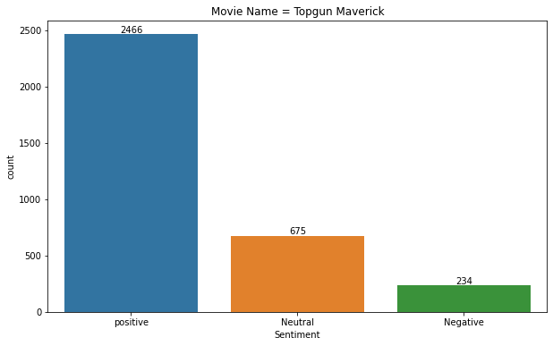

```python
plt.figure(figsize=(10,6))
ax=sns.countplot(x='Sentiment',data=data)
ax.bar_label(ax.containers[0])
plt.title('Movie Name = Topgun Maverick')
plt.show()
```

```python
data.to_csv('Topgun_Maverick_Sentient')
```

```python
driver.quit()
```

### Creating function for sentiment analysis

```python
def Sentiment_result(inp):
    print('Initializing driver.....')
    url='https://www.youtube.com/results?search_query={}'.format(inp)
    driver = start_chrome(maximize=True)
    print('Navigating to URL.....')
    go_to(url)
    time.sleep(2)
    driver.find_element_by_id("video-title").click()
    time.sleep(2)
    click(Point(200, 300))
    time.sleep(2)
    driver.execute_script('window.scrollTo(0,300);')
    time.sleep(2)
    button=driver.find_element_by_id("icon-label")
    time.sleep(2)
    button.click()
    time.sleep(1)
    sort=driver.find_element_by_xpath("/html/body/ytd-app/div[1]/ytd-page-manager/ytd-watch-flexy/div[5]/div[1]/div/ytd-comments/ytd-item-section-renderer/div[1]/ytd-comments-header-renderer/div[1]/span/yt-sort-filter-sub-menu-renderer/yt-dropdown-menu/tp-yt-paper-menu-button/tp-yt-iron-dropdown/div/div/tp-yt-paper-listbox/a[1]")
    sort.click()
    print('Comments sorted by top comments......')
    print('Loading started........')
    h=0
    for i in tqdm(range(500)):
        scroll_down(h)
        time.sleep(1)
        h+=300
    time.sleep(10)
    print('Scrapping started........')
    com=[i.text for i in driver.find_elements_by_id('content-text')]
    print('Scraping done.....raw output file created.')
    driver.quit()
    data=pd.DataFrame()
    data['Comments']=com
    data['Polarity']=[TextBlob(i).sentiment.polarity for i in data['Comments']]
    def senti(x):
        if x<0:
            return "Negative"
        elif  x ==0:
            return "Neutral"
        else:
            return "positive"
    data['Sentiment'] = data['Polarity'].apply(senti)
    plt.figure(figsize=(10,6))
    ax=sns.countplot(x='Sentiment',data=data)
    ax.bar_label(ax.containers[0])
    plt.title(f"Movie Name = {inp}")
    plt.show()
```

```
Initializing driver.....
Navigating to URL.....
```

```
Comments sorted by top comments......
Loading started........
```

```
Scrapping started........
Scraping done.....raw output file created.
```

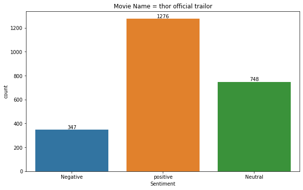

```python
Sentiment_result('thor official trailor')
```

```
Initializing driver.....
Navigating to URL.....
```

```
Comments sorted by top comments......
Loading started........
```

```
Scrapping started........
Scraping done.....raw output file created.
```

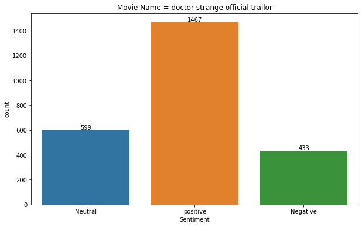

```python
Sentiment_result('doctor strange official trailor')
```

```
Initializing driver.....
Navigating to URL.....
```

```
Comments sorted by top comments......
Loading started........
```

```
Scrapping started........
Scraping done.....raw output file created.
```

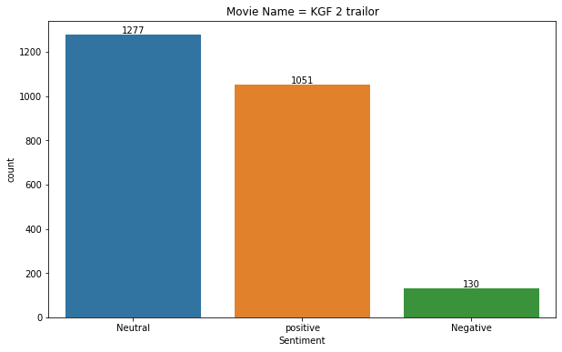

```python
Sentiment_result('KGF 2 trailor')
```

## Comments:

'-----------------------------------------------------------------------END--------------------------------------------------------------------------'